# Proxy Models for Micronutrient Deficiency

A Simulation-Based Tutorial Using Super Learner Ensembles

Author

Micronutrient Prediction Pipeline — Tutorial

Published

February 25, 2026

# 1 A. Motivation and Problem Setup

## 1.1 Why proxy models?

Micronutrient deficiency — insufficient serum ferritin (iron), retinol-binding protein (Vitamin A), zinc, or folate — affects billions globally, with the highest burden in sub-Saharan Africa and South Asia. Measuring deficiency requires a venous blood draw, cold-chain sample storage, and laboratory biochemical assay. A nationally representative biomarker survey therefore costs millions of dollars and may only be conducted once per decade.

**Proxy modeling** asks a different question: *given cheap, widely available covariates (satellite imagery, household surveys, census data), can we train a model on the expensive biomarker data and then predict deficiency prevalence everywhere — including places and time-points never sampled?*

This tutorial teaches the full pipeline: simulation, preprocessing, ensemble modeling, prevalence aggregation, uncertainty quantification, and spatial analysis.

## 1.2 Three prediction targets

Let $Y_i$ be a continuous biomarker (e.g., log ferritin, µg/L) and $D_i = \mathbf{1}[Y_i < c]$ the deficiency indicator for individual $i$, where $c$ is a clinical threshold. Let $X_i$ be a vector of covariates and $A_i \in \{1,\ldots,K\}$ the Admin1 region.

We distinguish three targets:

**Target 1 — Individual continuous prediction:**
$$\hat{E}[Y_i \mid X_i] \quad \text{(squared-error loss)}$$

**Target 2 — Individual deficiency probability:**
$$\hat{P}(D_i = 1 \mid X_i) \quad \text{(logistic / Brier loss)}$$

**Target 3 — Admin1 area prevalence:**
$$p_a = E[D_i \mid A_i = a] = P(Y_i < c \mid A_i = a)$$

**Warning**

**Ecological pitfall.** A model with good individual-level AUC does *not* automatically yield good area-level prevalence estimates. Aggregating individual probabilities is unbiased for the plug-in estimator only if the predicted probabilities are well-calibrated. Miscalibration at the tails (where deficiency occurs) propagates directly into prevalence bias.

# 2 B. Simulated Data Generating Process

## 2.1 Design choices

We simulate a survey in a fictitious country with $K = 12$ Admin1 regions, each containing $C = 8$ clusters (EAs), each with $n_c = 15$ individuals ($N = 1{,}440$ total). This mirrors the structure of a Micronutrient Survey (MNS) or DHS-linked biomarker subsample.

## 2.2 The DGP for the continuous biomarker

$$Y_i = \underbrace{\mu_{a(i)}}_{\text{Admin1 RE}}
+ \underbrace{S(s_{c(i)})}_{\text{spatial field}}
+ \underbrace{u_{c(i)}}_{\text{cluster RE}}
+ \underbrace{f(X_i)}_{\text{covariate effects}}
+ \underbrace{\varepsilon_i}_{\text{noise}}$$

where:

- $\mu_a \sim \mathcal{N}(0, \sigma_a^2)$, $\sigma_a = 0.4$
- $S(s) \sim \mathcal{GP}(0, K_{\text{exp}})$ with $K_{\text{exp}}(d) = \sigma_s^2 \exp(-d/\rho)$, $\sigma_s = 0.5$, $\rho = 0.25$
- $u_c \sim \mathcal{N}(0, \sigma_c^2)$, $\sigma_c = 0.3$
- $f(X_i)$ includes malaria, wealth, WASH, age (U-shaped), supplementation
- $\varepsilon_i \sim \mathcal{N}(0, \sigma_\varepsilon^2)$, $\sigma_\varepsilon = 0.6$

The deficiency indicator is $D_i = \mathbf{1}[Y_i < -0.5]$.

```r
df <- simulate_mn_survey(
  n_admin1            = N_ADMIN1,
  clusters_per_admin1 = CLUSTERS_PER_A1,
  n_per_cluster       = N_PER_CLUSTER,
  seed                = SEED,
  deficiency_cutoff   = DEFICIENCY_CUT
)

cat("Dimensions:", nrow(df), "×", ncol(df), "\n")
```

```
#> Dimensions: 1440 × 20
```

```r
cat("National deficiency prevalence:",
    round(mean(df$D) * 100, 1), "%\n")
```

```
#> National deficiency prevalence: 35.3 %
```

```r
cat("Admin1 regions:", length(unique(df$admin1_name)), "\n")
```

```
#> Admin1 regions: 12
```

```r
cat("Clusters:", length(unique(df$cluster_id)), "\n")
```

```
#> Clusters: 96
```

```r
# Admin1-level true prevalence
true_prev <- true_admin1_prevalence(df, "admin1_name")
cat("Admin1 prevalence range:",
    round(min(true_prev) * 100, 1), "% –",
    round(max(true_prev) * 100, 1), "%\n")
```

```
#> Admin1 prevalence range: 10 % – 71.7 %
```

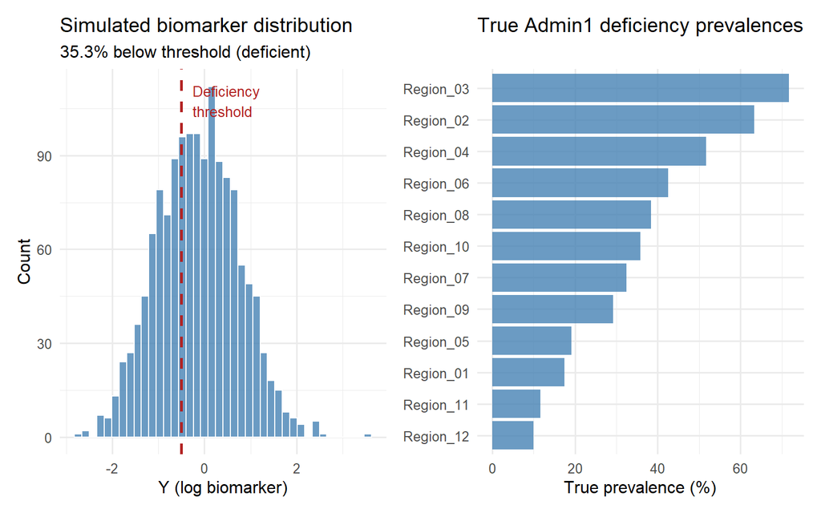

```r
# Biomarker distribution
p_hist <- ggplot(df, aes(x = Y)) +
  geom_histogram(bins = 40, fill = "steelblue", colour = "white", alpha = 0.8) +
  geom_vline(xintercept = DEFICIENCY_CUT, colour = "firebrick",
             linewidth = 1, linetype = "dashed") +
  annotate("text", x = DEFICIENCY_CUT + 0.05, y = Inf,
           label = "  Deficiency\n  threshold", vjust = 1.5,
           colour = "firebrick", size = 3.5, hjust = 0) +
  labs(x = "Y (log biomarker)", y = "Count",
       title = "Simulated biomarker distribution",
       subtitle = paste0(round(mean(df$D) * 100, 1),
                         "% below threshold (deficient)"))

p_prev <- ggplot(data.frame(admin1 = names(true_prev),
                             prev   = as.numeric(true_prev)),
                 aes(x = reorder(admin1, prev), y = prev * 100)) +
  geom_col(fill = "steelblue", alpha = 0.8) +
  coord_flip() +
  labs(x = NULL, y = "True prevalence (%)",
       title = "True Admin1 deficiency prevalences")

p_hist + p_prev
```

## 2.3 Survey weights

```r
prev_unwt  <- mean(df$D)
prev_wt    <- weighted.mean(df$D, df$svy_weight)
cat(sprintf("Unweighted national prevalence: %.1f%%\n", prev_unwt * 100))
```

```
#> Unweighted national prevalence: 35.3%
```

```r
cat(sprintf("Weighted   national prevalence: %.1f%%\n", prev_wt   * 100))
```

```
#> Weighted   national prevalence: 35.3%
```

# 3 C. Preprocessing and Feature Engineering

## 3.1 Missingness

We introduce MCAR missingness in `ses_educ` and `clim_temp` (5%), and MAR missingness in `dis_malaria` and `wash_sanitation` (up to 12%, higher for lower-SES individuals).

```r
df_miss <- introduce_missingness(
  df,
  mcar_vars = c("ses_educ", "clim_temp"),
  mar_vars  = c("dis_malaria", "wash_sanitation"),
  mcar_rate = 0.05,
  mar_rate  = 0.12,
  seed      = 7
)

# Missing rate per column
miss_rates <- sapply(df_miss, function(x) mean(is.na(x)))
miss_rates <- miss_rates[miss_rates > 0]
knitr::kable(data.frame(column     = names(miss_rates),
                         miss_pct   = round(miss_rates * 100, 1)),
             caption = "Missingness rates after introducing MCAR + MAR")
```

Missingness rates after introducing MCAR + MAR

|  | column | miss_pct |
| --- | --- | --- |
| wash_sanitation | wash_sanitation | 6.1 |
| ses_educ | ses_educ | 4.4 |
| clim_temp | clim_temp | 5.8 |
| dis_malaria | dis_malaria | 6.4 |

## 3.2 Imputation and standardisation

We impute with column medians and add binary missing-indicator columns (MAR allows the indicator itself to carry information):

```r
X_cols  <- get_predictor_cols(df_miss)
prep    <- preprocess_survey(df_train = df_miss, pred_cols = X_cols,
                              method = "indicator")
df_proc <- prep$data

cat("Predictor columns after preprocessing:", length(prep$pred_cols), "\n")
```

```
#> Predictor columns after preprocessing: 17
```

```r
cat("(includes", sum(startsWith(prep$pred_cols, "miss_")),
    "missing-indicator columns)\n")
```

```
#> (includes 4 missing-indicator columns)
```

## 3.3 Domain grouping

```r
domains <- make_domain_groups(df_proc)
purrr::iwalk(domains, ~cat(sprintf("  %-10s: %d columns\n", .y, length(.x))))
```

```
#>   wash      : 2 columns
#>   ses       : 2 columns
#>   climate   : 2 columns
#>   disease   : 2 columns
#>   indiv     : 4 columns
#>   spatial   : 2 columns
```

**Note**

# 4 D. Super Learner Modeling

## 4.1 Theoretical framework

Super Learner (van der Laan et al., 2007) finds the optimal convex combination of $M$ base learners by minimising cross-validated empirical risk:

$$\hat{\alpha} = \arg\min_{\alpha \in \Delta}
\frac{1}{K}\sum_{k=1}^{K} \frac{1}{n_k}
\sum_{i \in \mathcal{V}_k}
L\!\left(Y_i,\; \sum_{m=1}^{M} \alpha_m \hat{f}_m^{(-k)}(X_i)\right)$$

where $\Delta = \{\alpha : \alpha_m \ge 0,\; \sum_m \alpha_m = 1\}$ is the probability simplex, $\hat{f}_m^{(-k)}$ is learner $m$ trained on all folds except $k$, and $L$ is a loss function (squared error for continuous, log-loss for binary).

The **oracle property** guarantees that the Super Learner performs asymptotically as well as the best convex combination of base learners.

## 4.2 Cluster-blocked cross-validation

Standard $K$-fold CV assigns individuals randomly to folds. With cluster sampling, individuals in the same cluster share unobserved cluster-level random effects — assigning cluster-mates to different folds leaks this information, producing overly optimistic CV risk estimates.

**Solution:** assign all individuals in a cluster to the same fold.

```r
folds <- make_folds_cluster(cluster_id = df_proc$cluster_id,
                             V = V_FOLDS, seed = SEED)
# Verify: no cluster spans two folds
fold_vec <- integer(nrow(df_proc))
for (v in seq_along(folds)) fold_vec[folds[[v]]] <- v
df_proc$fold <- fold_vec

stopifnot(
  df_proc %>%
    group_by(cluster_id) %>%
    summarise(n_folds = n_distinct(fold)) %>%
    pull(n_folds) %>%
    max() == 1
)
cat("Cluster-blocked folds verified: each cluster is in exactly one fold.\n")
```

```
#> Cluster-blocked folds verified: each cluster is in exactly one fold.
```

```r
cat(sprintf("Fold sizes: %s individuals\n",
            paste(sapply(folds, length), collapse = ", ")))
```

```
#> Fold sizes: 300, 285, 285, 285, 285 individuals
```

## 4.3 Base learner library

```r
SL_LIBRARY <- c(
  "SL.mean",         # intercept-only baseline
  "SL.glmnet",       # elastic net (alpha tuned by inner CV)
  "SL.randomForest",  # random forest (500 trees)
  #"SL.ranger_fast",  # random forest (200 trees)
  "SL.mgcv_gam",     # penalised GAM (smooth terms)
  "SL.gam_spatial"   # GAM + 2-D thin-plate spline on coordinates
)
cat("Base learners:", paste(SL_LIBRARY, collapse = ", "), "\n")
```

```
#> Base learners: SL.mean, SL.glmnet, SL.randomForest, SL.mgcv_gam, SL.gam_spatial
```

## 4.4 Continuous biomarker model

```r
cat("Fitting continuous SuperLearner (Y ~ X)...\n")
```

```
#> Fitting continuous SuperLearner (Y ~ X)...
```

```r
fit_sl_continuous= function(df,
                               outcome    = "Y",
                               X_cols     = NULL,
                               foldid     = NULL,
                               sl_library = c("SL.mean", "SL.glmnet",
                                              "SL.randomForest",
                                              #"SL.ranger_fast",
                                              "SL.mgcv_gam",
                                              "SL.gam_spatial"),
                               ...) {
  if (is.null(X_cols))
    X_cols <- get_predictor_cols(df)

  # Drop all-NA columns
  X_cols <- X_cols[X_cols %in% colnames(df)]
  X_cols <- X_cols[!sapply(df[, X_cols, drop = FALSE],
                            function(x) all(is.na(x)))]

  Y <- df[[outcome]]
  X <- df[, X_cols, drop = FALSE]

  cv_control <- if (!is.null(foldid)) list(validRows = foldid, V=length(foldid)) else list(V = 5L)

  SuperLearner::SuperLearner(
    Y          = Y,
    X          = X,
    family     = gaussian(),
    SL.library = sl_library,
    cvControl  = cv_control,
    ...
  )
}

sl_cont <- fit_sl_continuous(
  df      = df_proc,
  outcome = "Y",
  X_cols  = prep$pred_cols,
  foldid  = folds,
  sl_library = SL_LIBRARY)
cat("Done.\n")
```

```
#> Done.
```

```r
# CV predictions (out-of-fold)
df_proc$pred_cont <- get_cv_preds(sl_cont)

# Metalearner weights
wt_cont <- summarise_sl_weights(sl_cont)
knitr::kable(wt_cont, caption = "Continuous model: metalearner weights")
```

Continuous model: metalearner weights

| learner | weight | cv_risk |
| --- | --- | --- |
| SL.mean_All | 0.3944 | 0.770941 |
| SL.gam_spatial_All | 0.2811 | 0.712500 |
| SL.randomForest_All | 0.2215 | 0.594110 |
| SL.glmnet_All | 0.1030 | 0.634216 |
| SL.mgcv_gam_All | 0.0000 | 0.789043 |

```r
metrics_cont <- compute_metrics(df_proc$Y, df_proc$pred_cont, "continuous")
cat("Continuous model performance (5-fold cluster-blocked CV):\n")
```

```
#> Continuous model performance (5-fold cluster-blocked CV):
```

```r
print_summary(metrics_cont)
```

```
#>   rmse                 0.6896
#>   mae                  0.5539
#>   r2                   0.3819
#>   pearson_r            0.8527
```

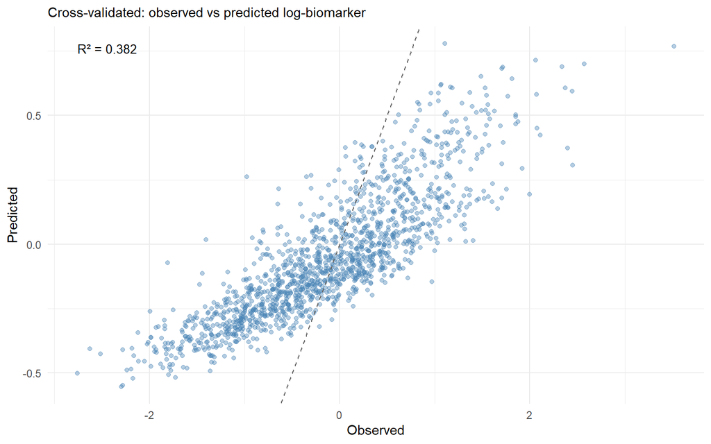

```r
make_scatter(df_proc$Y, df_proc$pred_cont,
             label = "Cross-validated: observed vs predicted log-biomarker")
```

## 4.5 Binary deficiency model

```r
cat("Fitting binary SuperLearner (D ~ X)...\n")
```

```
#> Fitting binary SuperLearner (D ~ X)...
```

```r
fit_sl_binary =  function(df,
                           outcome    = "D",
                           X_cols     = NULL,
                           foldid     = NULL,
                           sl_library = c("SL.mean", "SL.glmnet",
                                          "SL.ranger_fast",
                                          "SL.mgcv_gam",
                                          "SL.gam_spatial"),
                           ...) {
  if (is.null(X_cols))
    X_cols <- get_predictor_cols(df)

  X_cols <- X_cols[X_cols %in% colnames(df)]
  X_cols <- X_cols[!sapply(df[, X_cols, drop = FALSE],
                            function(x) all(is.na(x)))]

  Y <- as.numeric(df[[outcome]])
  X <- df[, X_cols, drop = FALSE]

  cv_control <- if (!is.null(foldid)) list(validRows = foldid, V=length(foldid)) else list(V = 5L)

  SuperLearner::SuperLearner(
    Y          = Y,
    X          = X,
    family     = binomial(),
    SL.library = sl_library,
    cvControl  = cv_control,
    ...
  )
}

sl_bin <- fit_sl_binary(
  df      = df_proc,
  outcome = "D",
  X_cols  = prep$pred_cols,
  foldid  = folds,
  sl_library = SL_LIBRARY
)
cat("Done.\n")
```

```
#> Done.
```

```r
df_proc$pred_bin <- get_cv_preds(sl_bin)

wt_bin <- summarise_sl_weights(sl_bin)
knitr::kable(wt_bin, caption = "Binary model: metalearner weights")
```

Binary model: metalearner weights

| learner | weight | cv_risk |
| --- | --- | --- |
| SL.randomForest_All | 0.4155 | 0.199167 |
| SL.gam_spatial_All | 0.4116 | 0.200180 |
| SL.glmnet_All | 0.1729 | 0.202538 |
| SL.mean_All | 0.0000 | 0.229196 |
| SL.mgcv_gam_All | 0.0000 | 0.219974 |

```r
metrics_bin <- compute_metrics(df_proc$D, df_proc$pred_bin, "binary")
cat("Binary model performance:\n")
```

```
#> Binary model performance:
```

```r
print_summary(metrics_bin)
```

```
#>   brier                0.096
#>   auc                  0.9751
#>   pr_auc               0.954
#>   cal_slope            3.9044
#>   cal_int              0.84
```

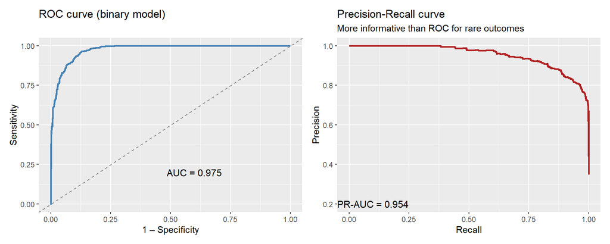

```r
roc_obj <- pROC::roc(df_proc$D, df_proc$pred_bin, quiet = TRUE)
pr_obj  <- PRROC::pr.curve(
  scores.class0 = df_proc$pred_bin[df_proc$D == 1],
  scores.class1 = df_proc$pred_bin[df_proc$D == 0],
  curve = TRUE
)

# ROC
roc_df <- data.frame(fpr = 1 - roc_obj$specificities,
                      tpr = roc_obj$sensitivities)
p_roc <- ggplot(roc_df, aes(fpr, tpr)) +
  geom_line(colour = "steelblue", linewidth = 1) +
  geom_abline(linetype = "dashed", colour = "grey50") +
  annotate("text", 0.6, 0.2,
           label = sprintf("AUC = %.3f", metrics_bin$auc), size = 4) +
  labs(x = "1 – Specificity", y = "Sensitivity",
       title = "ROC curve (binary model)")

# PR
pr_df <- as.data.frame(pr_obj$curve)
names(pr_df) <- c("recall", "precision", "threshold")
p_pr  <- ggplot(pr_df, aes(recall, precision)) +
  geom_line(colour = "firebrick", linewidth = 1) +
  annotate("text", 0.1, 0.2,
           label = sprintf("PR-AUC = %.3f", metrics_bin$pr_auc), size = 4) +
  labs(x = "Recall", y = "Precision",
       title = "Precision-Recall curve",
       subtitle = "More informative than ROC for rare outcomes")

p_roc + p_pr
```

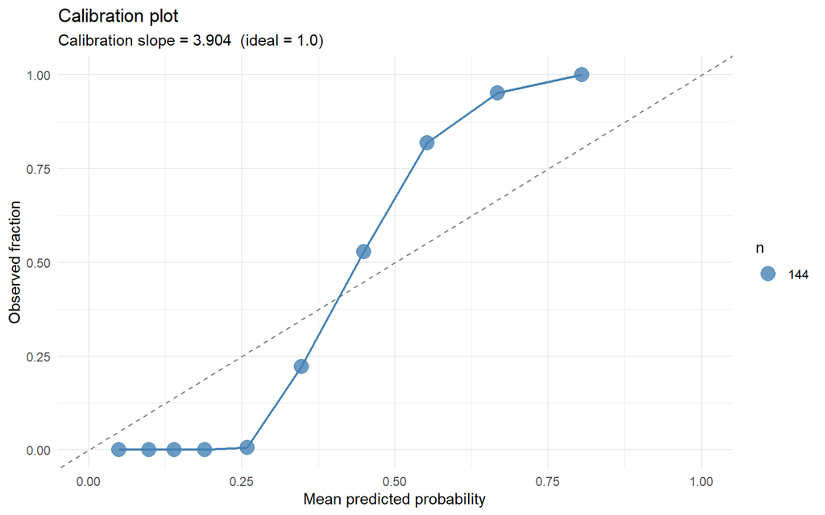

```r
calibration_plot(df_proc$D, df_proc$pred_bin, n_bins = 10) +
  labs(subtitle = sprintf("Calibration slope = %.3f  (ideal = 1.0)",
                           metrics_bin$cal_slope))
```

# 5 E. From Individual Predictions to Admin1 Prevalence

We implement and compare four aggregation approaches.

## 5.1 Approach 1: Plug-in mean of predicted probabilities

$$\hat{p}_a^{\text{plug}} = \frac{1}{N_a} \sum_{i:\, A_i = a} \hat{P}(D_i = 1 \mid X_i)$$

```r
prev_plugin <- prevalence_plugin(df_proc, "admin1_name", "pred_bin")
```

## 5.2 Approach 2: Cluster-level binomial model

Aggregate to cluster: $y_c = \sum D_i$, $n_c$, then fit $y_c \sim \text{Binomial}(n_c, p_c)$ with cluster-mean covariates as predictors, finally average predicted $\hat{p}_c$ within Admin1.

```r
prev_clust_bin <- prevalence_cluster_binomial(
  df_proc,
  admin1_col  = "admin1_name",
  cluster_col = "cluster_id",
  outcome     = "D",
  X_cols      = prep$pred_cols
)
```

## 5.3 Approach 3: Calibration-corrected prevalence

Fit logistic recalibration on held-out CV predictions:
$$\text{logit}(P(D=1)) = \beta_0 + \beta_1\,\text{logit}(\hat{p})$$

```r
prev_cal <- prevalence_calibrated(
  df_proc,
  admin1_col  = "admin1_name",
  obs_col     = "D",
  cv_pred_col = "pred_bin"
)
```

## 5.4 Approach 4: Threshold continuous prediction

$$\hat{D}_i = \mathbf{1}[\hat{Y}_i < c]$$
then average within Admin1. A **soft** version uses the Gaussian tail:
$$\hat{p}_i = P(Y_i < c \mid \hat{Y}_i) = \Phi\!\left(\frac{c - \hat{Y}_i}{\hat{\sigma}_\varepsilon}\right)$$

```r
resid_sd <- sd(df_proc$Y - df_proc$pred_cont, na.rm = TRUE)
cat("Estimated residual SD:", round(resid_sd, 3), "\n")
```

```
#> Estimated residual SD: 0.685
```

```r
# Hard threshold
prev_hard_thresh <- prevalence_threshold_continuous(
  df_proc, "admin1_name", "pred_cont",
  cutoff = DEFICIENCY_CUT, direction = "less"
)

# Soft threshold (probabilistic)
prev_soft_thresh <- prevalence_threshold_continuous(
  df_proc, "admin1_name", "pred_cont",
  cutoff = DEFICIENCY_CUT, direction = "less",
  residual_sd = resid_sd
)
```

## 5.5 Comparison of all four approaches

```r
est_list <- list(
  "1_plugin"       = prev_plugin,
  "2_cluster_bin"  = prev_clust_bin,
  "3_calibrated"   = prev_cal,
  "4a_hard_thresh" = prev_hard_thresh,
  "4b_soft_thresh" = prev_soft_thresh
)

comp_df <- compare_prevalence_approaches(true_prev, est_list)
err_tbl <- approach_error_summary(comp_df)

knitr::kable(err_tbl,
  col.names = c("Approach", "MAE (pp)", "RMSE (pp)", "Mean bias (pp)"),
  caption = "Admin1 prevalence estimation error (percentage points)")
```

Admin1 prevalence estimation error (percentage points)

| Approach | MAE (pp) | RMSE (pp) | Mean bias (pp) |
| --- | --- | --- | --- |
| 1_plugin | 2.02 | 2.52 | 0.28 |
| 2_cluster_bin | 8.65 | 11.16 | 0.00 |
| 3_calibrated | 6.34 | 7.41 | 0.00 |
| 4a_hard_thresh | 34.86 | 39.32 | -34.86 |
| 4b_soft_thresh | 11.07 | 14.40 | -8.11 |

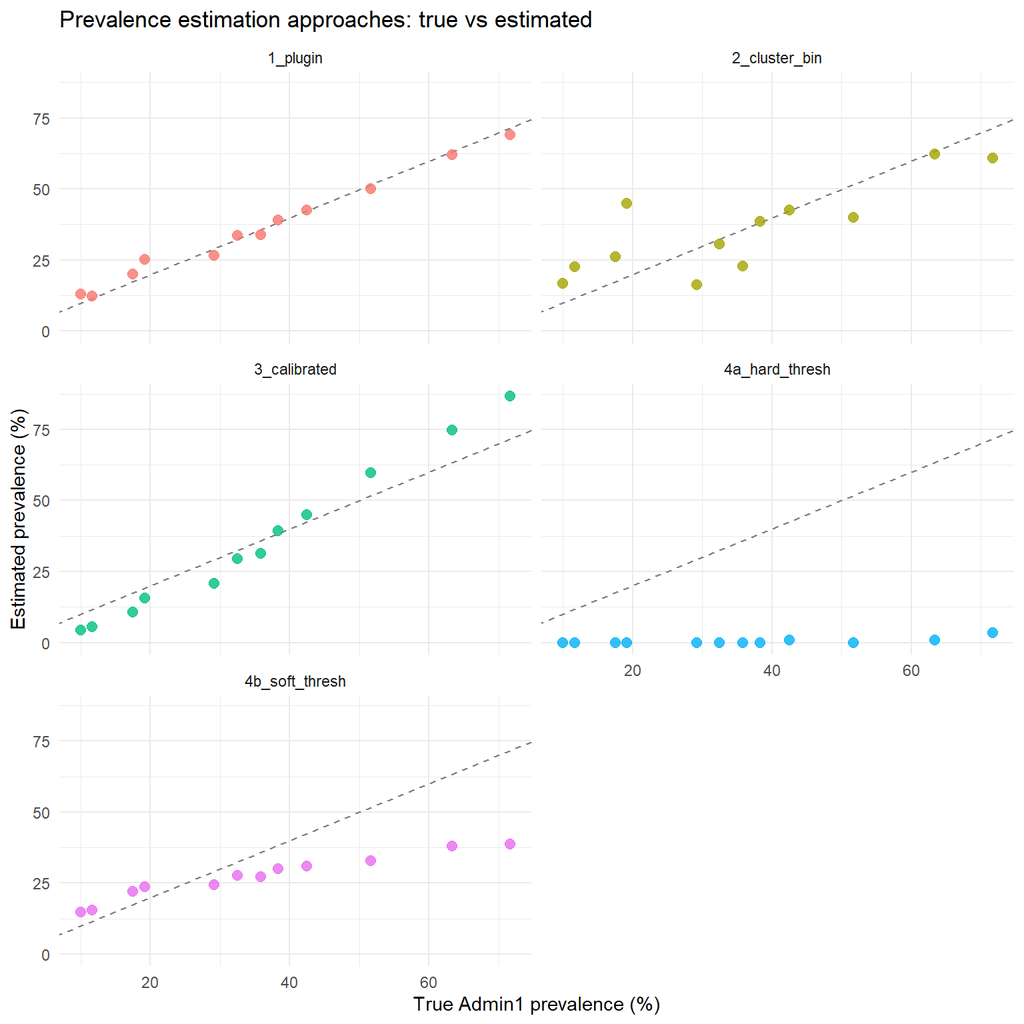

```r
plot_prevalence_comparison(comp_df)
```

**Note**

**Key observation.** The soft-threshold approach accounts for residual variance and tends to outperform hard thresholding when the model’s continuous predictions are noisy near the cutoff. The plug-in approach is unbiased when predicted probabilities are well-calibrated.

# 6 F. Uncertainty Quantification

## 6.1 Sources of uncertainty

| Source | Description | How to quantify |
| --- | --- | --- |
| Prediction uncertainty | Model uncertainty about $P(D=1\mid X)$ | Bootstrap refit, Bayesian posteriors |
| Sampling uncertainty | Finite survey sample | Survey design variance, delta method |
| Spatial interpolation | Predicting at unsampled locations | GP posterior variance, kriging SE |

## 6.2 Fast cluster bootstrap

We resample clusters with replacement and re-aggregate stored CV predictions (no refitting — a lower bound on true bootstrap variance).

```r
cat("Running fast bootstrap (B =", B_BOOT, ")...\n")
```

```
#> Running fast bootstrap (B = 100 )...
```

```r
boot_res <- bootstrap_fast_admin1(
  df          = df_proc,
  cluster_col = "cluster_id",
  admin1_col  = "admin1_name",
  pred_col    = "pred_bin",
  B           = B_BOOT,
  seed        = SEED
)
cat("Done.\n")
```

```
#> Done.
```

```r
knitr::kable(boot_res$ci %>% dplyr::mutate(across(where(is.numeric), ~round(.*100,1))),
  col.names = c("Admin1","Mean (%)","CI lo (%)","CI hi (%)","Width (pp)"),
  caption   = "Bootstrap 95% CIs for Admin1 deficiency prevalence")
```

Bootstrap 95% CIs for Admin1 deficiency prevalence

|  | Admin1 | Mean (%) | CI lo (%) | CI hi (%) | Width (pp) |
| --- | --- | --- | --- | --- | --- |
| Region_01 | Region_01 | 20.2 | 13.8 | 26.7 | 13.0 |
| Region_02 | Region_02 | 62.2 | 52.3 | 70.7 | 18.4 |
| Region_03 | Region_03 | 69.3 | 60.7 | 77.5 | 16.9 |
| Region_04 | Region_04 | 49.4 | 37.4 | 58.6 | 21.3 |
| Region_05 | Region_05 | 25.0 | 19.5 | 33.1 | 13.6 |
| Region_06 | Region_06 | 41.5 | 32.4 | 51.5 | 19.1 |
| Region_07 | Region_07 | 33.5 | 26.0 | 41.8 | 15.8 |
| Region_08 | Region_08 | 38.7 | 30.1 | 48.8 | 18.8 |
| Region_09 | Region_09 | 26.2 | 15.8 | 36.9 | 21.0 |
| Region_10 | Region_10 | 33.9 | 23.1 | 46.4 | 23.3 |
| Region_11 | Region_11 | 12.1 | 7.2 | 19.2 | 12.0 |
| Region_12 | Region_12 | 12.8 | 6.1 | 19.7 | 13.5 |

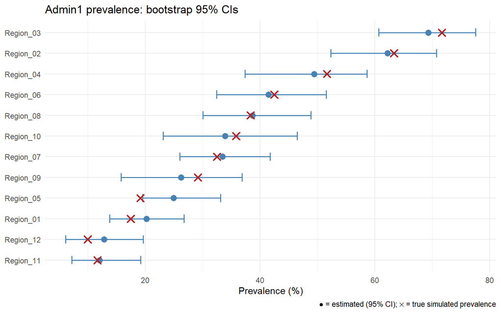

```r
plot_prevalence_ci(true_prev, boot_res$ci,
                   mean_col = "boot_mean",
                   title    = "Admin1 prevalence: bootstrap 95% CIs")
```

## 6.3 Delta-method variance

Under independence assumptions, the delta-method approximates $\text{Var}(\hat{p}_a)$ using the between-cluster variance of predicted means:

```r
dm_ci <- delta_method_admin1(df_proc, "admin1_name", "cluster_id", "pred_bin")
knitr::kable(dm_ci %>% mutate(across(where(is.numeric), ~round(.*100,2))),
  caption = "Delta-method 95% CIs (percentage points)")
```

Delta-method 95% CIs (percentage points)

| admin1_name | mean_pred | n_clusters | var_between | se_delta | ci_lo | ci_hi |
| --- | --- | --- | --- | --- | --- | --- |
| Region_01 | 19.97 | 800 | 0.14 | 3.73 | 12.67 | 27.28 |
| Region_02 | 62.05 | 800 | 0.24 | 4.94 | 52.37 | 71.73 |
| Region_03 | 68.93 | 800 | 0.20 | 4.44 | 60.22 | 77.64 |
| Region_04 | 50.07 | 800 | 0.31 | 5.61 | 39.09 | 61.06 |
| Region_05 | 25.14 | 800 | 0.14 | 3.72 | 17.85 | 32.43 |
| Region_06 | 42.53 | 800 | 0.33 | 5.74 | 31.27 | 53.78 |
| Region_07 | 33.66 | 800 | 0.14 | 3.76 | 26.28 | 41.04 |
| Region_08 | 39.03 | 800 | 0.22 | 4.68 | 29.86 | 48.20 |
| Region_09 | 26.43 | 800 | 0.26 | 5.06 | 16.50 | 36.35 |
| Region_10 | 33.74 | 800 | 0.33 | 5.71 | 22.54 | 44.94 |
| Region_11 | 12.24 | 800 | 0.14 | 3.71 | 4.98 | 19.51 |
| Region_12 | 12.90 | 800 | 0.12 | 3.48 | 6.08 | 19.73 |

## 6.4 GAM-based Monte Carlo uncertainty

For the spatial GAM fitted below (Section G), we propagate coefficient uncertainty via Monte Carlo draws from the Gaussian posterior:

```r
# Fit a standalone spatial GAM for illustration
gam_fit_unc <- mgcv::gam(
  D ~ s(x_coord, y_coord, bs = "tp", k = 20) +
      dis_malaria + ses_wealth + wash_water,
  data   = df_proc,
  family = binomial(),
  method = "REML"
)

gam_ci <- gam_uncertainty_admin1(
  gam_fit  = gam_fit_unc,
  newdata  = df_proc,
  admin1_col = "admin1_name",
  n_sim    = 300
)
knitr::kable(gam_ci %>% mutate(across(where(is.numeric), ~round(.*100,2))),
  caption = "GAM Monte Carlo 95% CIs (percentage points)")
```

GAM Monte Carlo 95% CIs (percentage points)

|  | admin1 | gam_mean | ci_lo | ci_hi |
| --- | --- | --- | --- | --- |
| Region_01 | Region_01 | 22.48 | 15.80 | 29.75 |
| Region_02 | Region_02 | 61.76 | 52.90 | 68.68 |
| Region_03 | Region_03 | 70.10 | 62.74 | 77.49 |
| Region_04 | Region_04 | 48.31 | 39.21 | 56.02 |
| Region_05 | Region_05 | 20.50 | 15.12 | 26.89 |
| Region_06 | Region_06 | 41.20 | 33.35 | 49.95 |
| Region_07 | Region_07 | 33.83 | 26.05 | 41.94 |
| Region_08 | Region_08 | 40.45 | 33.05 | 49.22 |
| Region_09 | Region_09 | 29.58 | 22.17 | 37.13 |
| Region_10 | Region_10 | 35.56 | 27.26 | 44.08 |
| Region_11 | Region_11 | 9.82 | 5.60 | 14.85 |
| Region_12 | Region_12 | 12.24 | 7.93 | 18.91 |

## 6.5 Cross-fold variability heuristic

```r
fold_var <- cv_fold_variability(df_proc, "fold", "pred_bin", "admin1_name")
knitr::kable(fold_var %>% mutate(across(where(is.numeric), ~round(.*100,2))),
  caption = "Fold-to-fold Admin1 prevalence variability (NOT a valid CI)")
```

Fold-to-fold Admin1 prevalence variability (NOT a valid CI)

| admin1_name | fold_mean | fold_sd | fold_min | fold_max |
| --- | --- | --- | --- | --- |
| Region_01 | 22.83 | 12.77 | 12.29 | 42.66 |
| Region_02 | 66.02 | 10.06 | 56.52 | 80.18 |
| Region_03 | 67.42 | 5.32 | 59.71 | 71.83 |
| Region_04 | 50.61 | 20.04 | 19.23 | 73.17 |
| Region_05 | 26.74 | 6.87 | 20.33 | 33.98 |
| Region_06 | 40.97 | 11.69 | 29.03 | 56.71 |
| Region_07 | 33.80 | 9.64 | 21.90 | 42.18 |
| Region_08 | 39.41 | 12.31 | 24.32 | 58.03 |
| Region_09 | 26.43 | 6.34 | 17.28 | 31.80 |
| Region_10 | 33.10 | 4.35 | 29.79 | 38.96 |
| Region_11 | 11.73 | 5.32 | 6.65 | 18.87 |
| Region_12 | 13.80 | 10.57 | 5.37 | 28.80 |

**Warning**

Cross-fold variability describes model instability, not sampling uncertainty. It should *not* be reported as a confidence interval.

# 7 G. Spatial Autocorrelation and Mapping

## 7.1 Moran’s I on cluster residuals

```r
# Compute cluster-level residuals from continuous model
cl_resid <- cluster_residuals(df_proc, "cluster_id", "Y", "pred_cont")

mi <- compute_morans_i(
  residuals = cl_resid$mean_residual,
  coords    = cl_resid[, c("x_coord", "y_coord")],
  k = 6, nsim = 499
)
cat(sprintf("Moran's I = %.4f,  p-value = %.4f\n", mi$I, mi$p_value))
```

```
#> Moran's I = 0.3145,  p-value = 0.0020
```

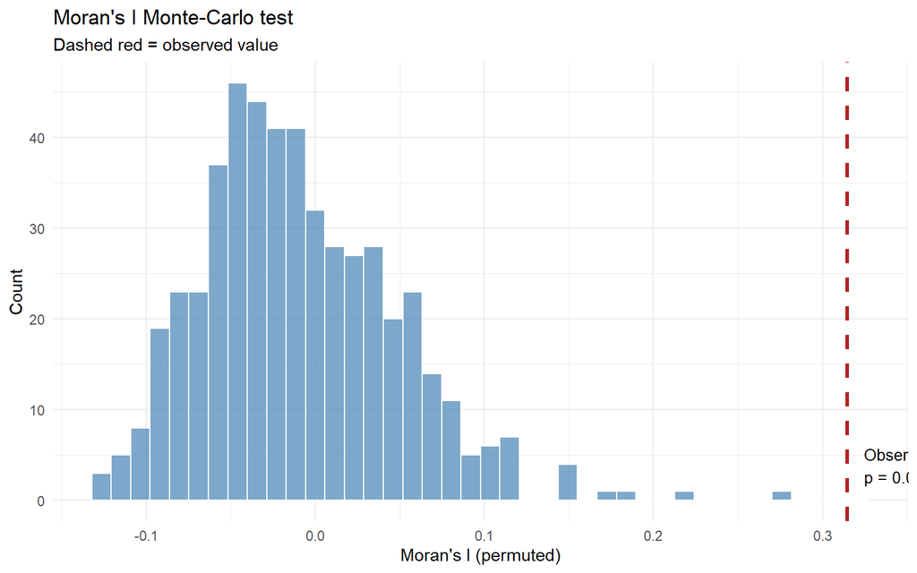

```r
mi$plot
```

## 7.2 Empirical variogram

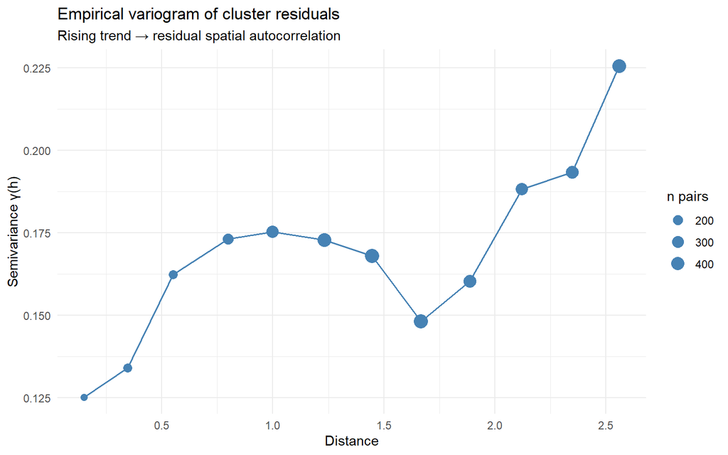

```r
vario <- empirical_variogram(cl_resid, n_bins = 12)
plot_variogram(vario)
```

## 7.3 Wall-to-wall grid prediction

```r
# Simulate covariate grid
grid_raw <- simulate_covariate_grid(resolution = 0.05, seed = 99)

# Apply training preprocessing stats
grid_proc <- apply_preprocessing(grid_raw,
                                   impute_stats  = prep$impute_stats,
                                   scale_params  = prep$scale_params,
                                   method        = "indicator")

predict_grid <- function(sl_fit, grid_df, X_cols) {
  # Align columns to those used in fitting
  fit_cols <- (sl_fit$varNames)
  available <- intersect(fit_cols, colnames(grid_df))
  missing_cols <- setdiff(fit_cols, colnames(grid_df))

  newX <- grid_df[, available, drop = FALSE]
  for (col in missing_cols) newX[[col]] <- 0   # fill missing with 0

  newX <- newX[, fit_cols, drop = FALSE]        # exact column order

  preds <- predict(sl_fit, newdata = newX)$pred
  grid_df$sl_pred <- as.numeric(preds)
  grid_df
}

# Predict continuous biomarker
grid_proc <- predict_grid(sl_cont, grid_proc, prep$pred_cols)
names(grid_proc)[names(grid_proc) == "sl_pred"] <- "pred_cont"

# Predict deficiency probability using binary model
grid_proc2 <- predict_grid(sl_bin, grid_proc, prep$pred_cols)
grid_proc$pred_prob <- grid_proc2$sl_pred
grid_proc$pred_D    <- apply_threshold(grid_proc$pred_cont,
                                        DEFICIENCY_CUT, "less")
```

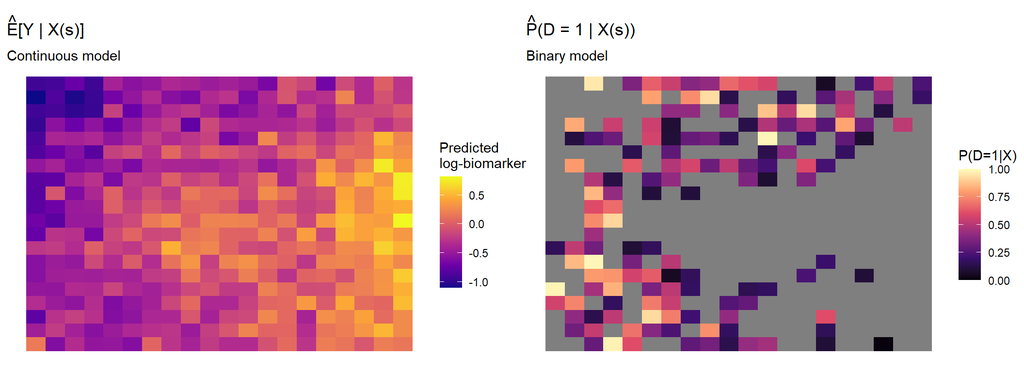

```r
p_grid_cont <- ggplot(grid_proc, aes(x = x_coord, y = y_coord,
                                      fill = pred_cont)) +
  geom_tile() +
  scale_fill_viridis_c(name = "Predicted\nlog-biomarker", option = "plasma") +
  labs(title = expression(hat(E)*"[Y | X(s)]"),
       subtitle = "Continuous model") +
  theme_void(base_size = 11) + theme(plot.title = element_text(face = "bold"))

p_grid_prob <- ggplot(grid_proc, aes(x = x_coord, y = y_coord,
                                      fill = pred_prob)) +
  geom_tile() +
  scale_fill_viridis_c(name = "P(D=1|X)",
                        limits = c(0, 1), option = "magma") +
  labs(title = expression(hat(P)*"(D = 1 | X(s))"),
       subtitle = "Binary model") +
  theme_void(base_size = 11) + theme(plot.title = element_text(face = "bold"))

p_grid_cont + p_grid_prob
```

## 7.4 Admin1 polygons and aggregation

```r
admin1_sf <- simulate_admin1_polygons(n_admin1 = N_ADMIN1, seed = SEED)
grid_proc <- assign_grid_to_admin1(grid_proc, admin1_sf)

# Grid-based Admin1 prevalence (area-weighted)
grid_a1 <- aggregate_to_admin1(grid_proc, "admin1_name", "pred_prob")
knitr::kable(grid_a1 %>% mutate(pred_prevalence = round(pred_prevalence*100,1)),
             caption = "Grid-aggregated Admin1 predicted prevalence (%)")
```

Grid-aggregated Admin1 predicted prevalence (%)

[output not shown]

[figure not shown]

```r
plot_admin1_map(admin1_sf, grid_a1,
                title = "Admin1 predicted deficiency prevalence (grid aggregation)")
```

## 7.5 Three approaches to spatial dependence

### 7.5.1 1. GAM with spatial smooth (coordinates as smooth term)

```r
gam_sp <- mgcv::gam(
  D ~ s(x_coord, y_coord, bs = "tp", k = 25) +
      dis_malaria + ses_wealth + wash_water + indiv_suppl,
  data   = df_proc,
  family = binomial(),
  method = "REML"
)
summary(gam_sp)$s.table |> round(4) |> knitr::kable(caption = "GAM smooth terms")
```

GAM smooth terms

|  | edf | Ref.df | Chi.sq | p-value |
| --- | --- | --- | --- | --- |
| s(x_coord,y_coord) | 21.2785 | 23.4052 | 235.1378 | 0 |

```r
df_proc$pred_gam_sp <- predict(gam_sp, type = "response")
```

### 7.5.2 2. Mixed model with Admin1 random effect

```r
# Fit GLMM with Admin1 random intercept using glmer
# (lme4 required; use glm + fixed effects as fallback)
mixed_fit <- tryCatch({
  if (requireNamespace("lme4", quietly = TRUE)) {
    lme4::glmer(
      D ~ dis_malaria + ses_wealth + wash_water + (1 | admin1_name),
      data   = df_proc,
      family = binomial(),
      control = lme4::glmerControl(optimizer = "bobyqa")
    )
  } else {
    glm(D ~ dis_malaria + ses_wealth + wash_water + factor(admin1_name),
        data = df_proc, family = binomial())
  }
}, error = function(e) {
  glm(D ~ dis_malaria + ses_wealth + wash_water + factor(admin1_name),
      data = df_proc, family = binomial())
})
df_proc$pred_mixed <- predict(mixed_fit, type = "response")
```

### 7.5.3 3. Spatially blocked cross-validation

```r
spatial_blocks <- make_spatial_blocks(df_proc[, c("x_coord","y_coord")],
                                       n_blocks = V_FOLDS, seed = SEED)
df_proc$spatial_block <- spatial_blocks
spatial_folds <- spatial_blocks_to_folds(spatial_blocks)

cat(sprintf("Spatial CV blocks: %d blocks, sizes %s\n",
            V_FOLDS, paste(sapply(spatial_folds, length), collapse = ", ")))
```

```
#> Spatial CV blocks: 5 blocks, sizes 240, 255, 240, 465, 240
```

```r
# Compare cluster CV vs spatial CV risk (using glmnet as a fast proxy)
make_glmnet_preds <- function(df, foldid, outcome = "D") {
  X   <- as.matrix(df[, c("dis_malaria","ses_wealth","wash_water",
                            "x_coord","y_coord")])
  Y   <- df[[outcome]]
  fit <- glmnet::cv.glmnet(X, Y, family = "binomial",
                             foldid = foldid, alpha = 0.5)
  as.numeric(predict(fit, X, s = "lambda.min", type = "response"))
}

# Cluster-blocked CV AUC
preds_clust <- make_glmnet_preds(df_proc, fold_vec)
auc_clust   <- as.numeric(pROC::auc(pROC::roc(df_proc$D, preds_clust, quiet=TRUE)))

# Spatial-block CV AUC
preds_spat  <- make_glmnet_preds(df_proc, spatial_blocks)
auc_spat    <- as.numeric(pROC::auc(pROC::roc(df_proc$D, preds_spat, quiet=TRUE)))

cat(sprintf("Cluster-blocked CV AUC: %.3f\n", auc_clust))
```

```
#> Cluster-blocked CV AUC: 0.683
```

```r
cat(sprintf("Spatial-block   CV AUC: %.3f\n", auc_spat))
```

```
#> Spatial-block   CV AUC: 0.664
```

```r
cat("(Spatial CV is typically more conservative due to larger effective test sets)\n")
```

```
#> (Spatial CV is typically more conservative due to larger effective test sets)
```

# 8 H. Loss Functions and Rare Outcomes

## 8.1 Why ROC-AUC can mislead

```r
# Artificially create a rare-outcome scenario (5% prevalence)
set.seed(123)
df_rare <- simulate_mn_survey(
  n_admin1 = N_ADMIN1, clusters_per_admin1 = CLUSTERS_PER_A1,
  n_per_cluster = N_PER_CLUSTER,
  deficiency_cutoff = -1.5,   # moves threshold left → ~5% prevalence
  seed = 123
)
cat("Rare outcome prevalence:", round(mean(df_rare$D)*100,1),"%\n")
```

```
#> Rare outcome prevalence: 7.4 %
```

```r
# A trivial "predict always zero" model
pred_zero    <- rep(0, nrow(df_rare))
pred_random  <- runif(nrow(df_rare))

auc_zero   <- as.numeric(pROC::auc(pROC::roc(df_rare$D, pred_zero, quiet=TRUE)))
prauc_zero <- PRROC::pr.curve(
  pred_zero[df_rare$D==1], pred_zero[df_rare$D==0])$auc.integral
brier_zero <- mean((df_rare$D - pred_zero)^2)

cat(sprintf("\nAlways-zero model:\n  ROC-AUC = %.3f (misleading!)\n",  auc_zero))
```

```
#>
#> Always-zero model:
#>   ROC-AUC = 0.500 (misleading!)
```

```r
cat(sprintf("  PR-AUC  = %.3f\n  Brier   = %.4f\n", prauc_zero, brier_zero))
```

```
#>   PR-AUC  = 0.074
#>   Brier   = 0.0743
```

## 8.2 Alternative losses

```r
# Demonstrate focal loss vs standard log loss
set.seed(1)
p_sim <- runif(500, 0, 1)
y_sim <- rbinom(500, 1, 0.1)

logloss_std  <- weighted_log_loss(y_sim, p_sim)
logloss_foc  <- focal_loss(y_sim, p_sim, gamma = 2, alpha = 0.75)
brier_loss   <- mean((y_sim - p_sim)^2)

data.frame(
  Loss    = c("Standard log-loss", "Focal (γ=2, α=0.75)", "Brier score"),
  Value   = round(c(logloss_std, logloss_foc, brier_loss), 4)
) |> knitr::kable(caption = "Loss values for a 10%-prevalence scenario")
```

Loss values for a 10%-prevalence scenario

| Loss | Value |
| --- | --- |
| Standard log-loss | 0.9749 |
| Focal (γ=2, α=0.75) | 0.1764 |
| Brier score | 0.3234 |

**Tip**

For **prevalence estimation**, the Brier score and calibration metrics are more actionable than ROC-AUC. Use PR-AUC for individual-level screening decisions. Train with focal or weighted log-loss only if you have strong evidence that it improves *prevalence* accuracy, not just classification.

# 9 I. Post-Hoc Threshold Tuning

## 9.1 Why thresholds matter

The binary model outputs $\hat{P}(D=1 \mid X) \in (0,1)$. Converting to a hard prediction requires a threshold $T$: $\hat{D} = \mathbf{1}[\hat{p} \ge T]$. The default $T = 0.5$ is rarely optimal.

## 9.2 Cost-based optimal threshold

Under a simple expected-cost framework with $C_{FP}$ (cost of false positive) and $C_{FN}$ (cost of false negative):

$$T^* = \frac{C_{FP}}{C_{FP} + C_{FN}}$$

```r
CFP <- 1   # treating a non-deficient person
CFN <- 5   # missing a deficient person

T_cost <- CFP / (CFP + CFN)
cat(sprintf("Cost-optimal threshold: T* = %.2f\n", T_cost))
```

```
#> Cost-optimal threshold: T* = 0.17
```

```r
cat(sprintf("(C_FP = %d, C_FN = %d → prioritises sensitivity)\n", CFP, CFN))
```

```
#> (C_FP = 1, C_FN = 5 → prioritises sensitivity)
```

```r
cm <- classification_metrics_at_T(df_proc$D, df_proc$pred_bin, T = T_cost)
knitr::kable(t(round(cm, 3)), caption = sprintf("Metrics at T* = %.2f", T_cost))
```

Metrics at T* = 0.17

| sensitivity | specificity | ppv | npv | f1 |
| --- | --- | --- | --- | --- |
| 1 | 0.481 | 0.512 | 1 | 0.677 |

## 9.3 Threshold comparison

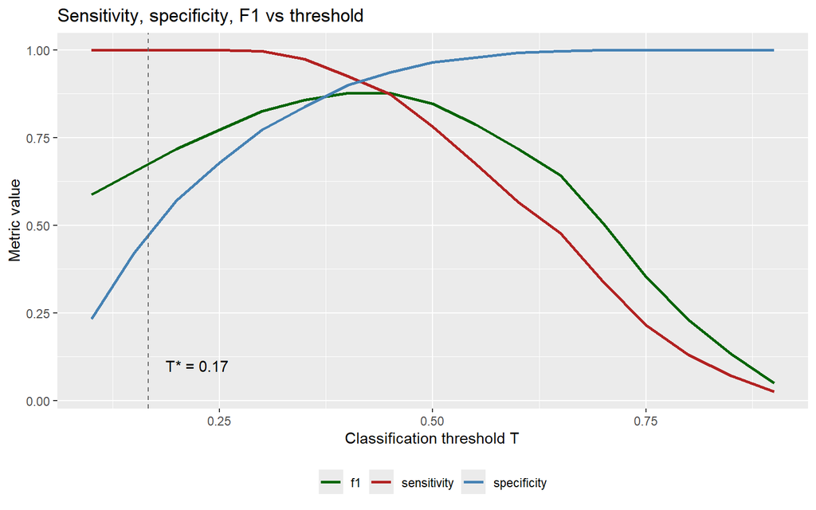

```r
T_grid <- seq(0.1, 0.9, by = 0.05)
thresh_df <- do.call(rbind, lapply(T_grid, function(t) {
  m <- classification_metrics_at_T(df_proc$D, df_proc$pred_bin, T = t)
  data.frame(T = t, as.list(m))
}))

thresh_long <- tidyr::pivot_longer(thresh_df, -T, names_to = "metric")

ggplot(thresh_long %>% filter(metric %in% c("sensitivity","specificity","f1")),
       aes(x = T, y = value, colour = metric)) +
  geom_line(linewidth = 1) +
  geom_vline(xintercept = T_cost, linetype = "dashed", colour = "grey40") +
  annotate("text", x = T_cost + 0.02, y = 0.1,
           label = sprintf("T* = %.2f", T_cost), hjust = 0) +
  scale_colour_manual(
    values = c(sensitivity = "firebrick", specificity = "steelblue", f1 = "darkgreen")
  ) +
  labs(x = "Classification threshold T",
       y = "Metric value",
       title = "Sensitivity, specificity, F1 vs threshold",
       colour = NULL) +
  theme(legend.position = "bottom")
```

## 9.4 Nested CV for honest threshold evaluation

**Warning**

**Bias warning.** Tuning $T$ on the same data used to report performance inflates sensitivity/specificity estimates. Use nested (double) CV: inner loop picks $T$, outer loop evaluates.

```r
# Simplified nested CV demonstration (outer = 3 folds for speed)
outer_folds <- make_folds_cluster(df_proc$cluster_id, V = 3, seed = 10)
nested_results <- list()

for (v_out in seq_along(outer_folds)) {
  val_idx   <- outer_folds[[v_out]]
  train_idx <- setdiff(seq_len(nrow(df_proc)), val_idx)
  df_train  <- df_proc[train_idx, ]
  df_val    <- df_proc[val_idx,   ]

  # Inner loop: tune T on training data predictions
  inner_folds <- make_folds_cluster(df_train$cluster_id, V = 3, seed = v_out)
  sl_inner <- tryCatch(
    fit_sl_binary(df_train, "D", prep$pred_cols, inner_folds,
                  sl_library = c("SL.mean", "SL.glmnet")),
    error = function(e) NULL
  )
  if (is.null(sl_inner)) next

  preds_inner <- get_cv_preds(sl_inner)
  T_inner     <- tune_threshold(df_train$D, preds_inner, criterion = "f1")

  # Outer evaluation: use T chosen in inner loop
  preds_val <- as.numeric(predict(sl_inner, newdata = df_val[, prep$pred_cols])$pred)
  cm_v      <- classification_metrics_at_T(df_val$D, preds_val, T = T_inner)
  nested_results[[v_out]] <- c(fold = v_out, T_chosen = T_inner, cm_v)
}

nested_df <- do.call(rbind, lapply(nested_results, as.data.frame))
knitr::kable(round(nested_df, 3),
             caption = "Nested CV: T chosen in inner loop, evaluated in outer")
```

Nested CV: T chosen in inner loop, evaluated in outer

|  | X[[i]] |
| --- | --- |
| fold | 1.000 |
| T_chosen | 0.330 |
| sensitivity | 0.631 |
| specificity | 0.737 |
| ppv | 0.621 |
| npv | 0.745 |
| f1 | 0.626 |
| fold1 | 2.000 |
| T_chosen1 | 0.300 |
| sensitivity1 | 0.822 |
| specificity1 | 0.466 |
| ppv1 | 0.417 |
| npv1 | 0.850 |
| f11 | 0.553 |
| fold2 | 3.000 |
| T_chosen2 | 0.310 |
| sensitivity2 | 0.671 |
| specificity2 | 0.558 |
| ppv2 | 0.434 |
| npv2 | 0.771 |
| f12 | 0.527 |

# 10 J. Variable Importance and Domain Contribution

## 10.1 Permutation importance (cluster-preserving)

```r
# Permutation importance: permute each variable, measure AUC drop.
# Permutations respect cluster structure (entire cluster permuted together).
compute_permutation_importance <- function(df, pred_col, outcome, X_cols,
                                            cluster_col, n_perm = 5) {
  base_auc <- as.numeric(pROC::auc(
    pROC::roc(df[[outcome]], df[[pred_col]], quiet = TRUE)))

  clusters <- unique(df[[cluster_col]])

  imp <- lapply(X_cols, function(v) {
    if (!(v %in% colnames(df))) return(NULL)
    auc_perm <- replicate(n_perm, {
      df_perm <- df
      # Permute whole clusters for this variable
      cl_vals  <- tapply(df[[v]], df[[cluster_col]], mean)
      perm_cls <- sample(names(cl_vals))
      for (i in seq_along(clusters)) {
        idx <- df[[cluster_col]] == clusters[i]
        df_perm[[v]][idx] <- cl_vals[perm_cls[i]]
      }
      # Refit would be ideal; here we approximate by measuring correlation drop
      cor_drop <- 1 - abs(cor(df[[v]], df_perm[[v]], use = "complete.obs"))
      cor_drop
    })
    data.frame(variable = v, importance = mean(auc_perm))
  })

  do.call(rbind, Filter(Negate(is.null), imp)) %>%
    dplyr::arrange(desc(importance))
}

top_cols <- head(prep$pred_cols[!startsWith(prep$pred_cols, "miss_")], 20)
varimp_df <- compute_permutation_importance(
  df_proc, "pred_bin", "D", top_cols, "cluster_id", n_perm = 5
)
```

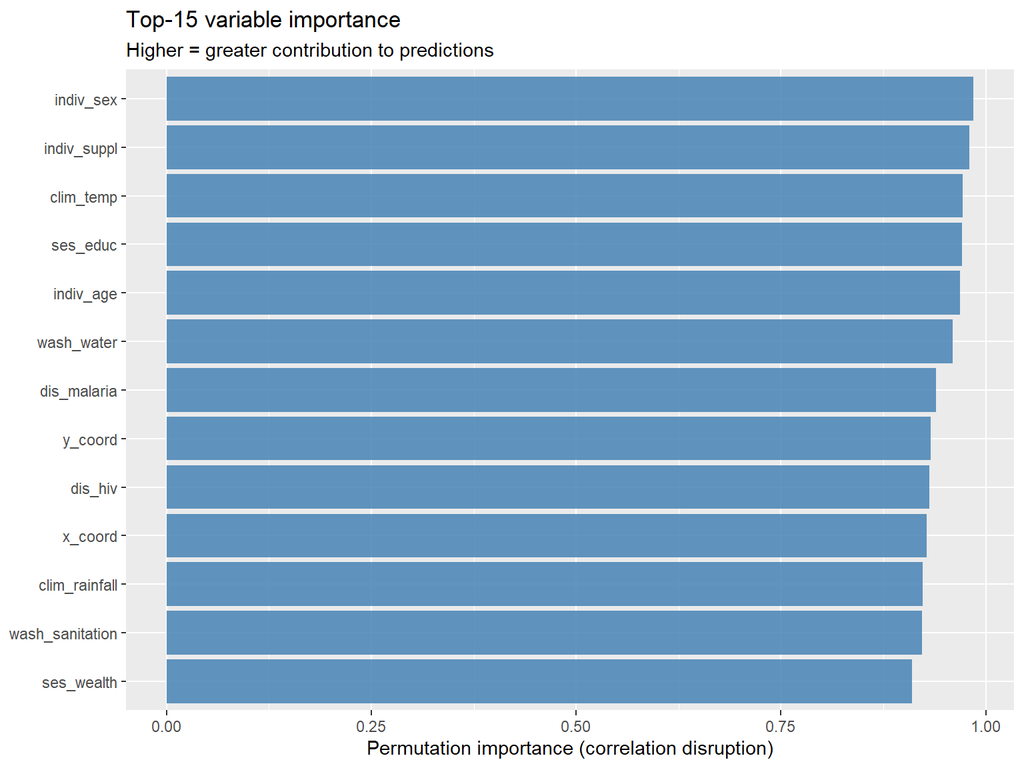

```r
varimp_df$variable <- factor(varimp_df$variable,
                               levels = varimp_df$variable[order(varimp_df$importance)])
ggplot(head(varimp_df, 15),
       aes(x = variable, y = importance)) +
  geom_col(fill = "steelblue", alpha = 0.85) +
  coord_flip() +
  labs(x = NULL, y = "Permutation importance (correlation disruption)",
       title = "Top-15 variable importance",
       subtitle = "Higher = greater contribution to predictions")
```

## 10.2 Grouped domain importance

```r
domain_grps <- make_domain_groups(df_proc)
domain_imp  <- lapply(names(domain_grps), function(dom) {
  dom_cols <- intersect(domain_grps[[dom]], varimp_df$variable)
  if (length(dom_cols) == 0) return(NULL)
  total <- sum(varimp_df$importance[varimp_df$variable %in% dom_cols])
  data.frame(domain = dom, total_importance = total, n_vars = length(dom_cols))
})
domain_imp_df <- do.call(rbind, Filter(Negate(is.null), domain_imp))
knitr::kable(domain_imp_df %>%
               mutate(total_importance = round(total_importance, 4)) %>%
               arrange(desc(total_importance)),
             caption = "Grouped domain importance (sum of permutation importance)")
```

Grouped domain importance (sum of permutation importance)

| domain | total_importance | n_vars |
| --- | --- | --- |
| indiv | 2.9336 | 3 |
| climate | 1.8946 | 2 |
| wash | 1.8814 | 2 |
| ses | 1.8814 | 2 |
| disease | 1.8696 | 2 |
| spatial | 1.8606 | 2 |

**Caution**

**Interpretation caveats.** (1) Correlated variables share importance — removing one may not reduce performance. (2) A domain with more variables mechanically accumulates more total importance. (3) Permutation importance measures predictive contribution, not causal effect.

# 11 K. Alternative Modeling Families

## 11.1 K.1 Spatial GAM (mgcv — stand-in for hierarchical Bayes)

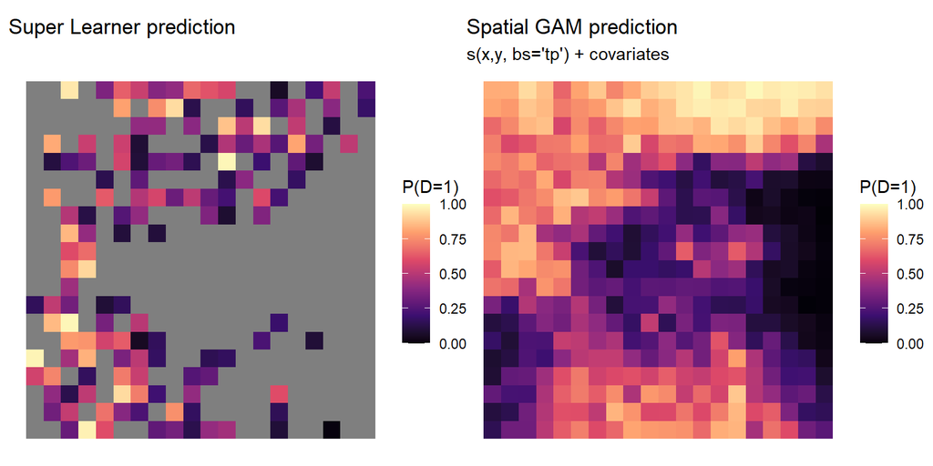

```r
# Already fitted above; predict on grid for comparison
grid_proc$pred_gam <- predict(gam_sp,
                               newdata = grid_proc, type = "response")

p_gam <- ggplot(grid_proc, aes(x_coord, y_coord, fill = pred_gam)) +
  geom_tile() +
  scale_fill_viridis_c("P(D=1)", limits = c(0,1), option = "magma") +
  labs(title = "Spatial GAM prediction",
       subtitle = "s(x,y, bs='tp') + covariates") +
  theme_void()

p_sl  <- ggplot(grid_proc, aes(x_coord, y_coord, fill = pred_prob)) +
  geom_tile() +
  scale_fill_viridis_c("P(D=1)", limits = c(0,1), option = "magma") +
  labs(title = "Super Learner prediction") +
  theme_void()

p_sl + p_gam
```

## 11.2 K.2 Fay-Herriot small area estimation

```r
# Direct survey estimates per Admin1 (design-based, treating our data as survey)
direct_est <- tapply(df_proc$D, df_proc$admin1_name, mean)
samp_var   <- tapply(df_proc$D, df_proc$admin1_name, function(x) var(x)/length(x))

# Admin1-level covariate design matrix
a1_covs <- df_proc %>%
  group_by(admin1_name) %>%
  summarise(dis_malaria = mean(dis_malaria),
            ses_wealth  = mean(ses_wealth),
            wash_water  = mean(wash_water))

fh_res <- fit_fay_herriot(direct_est, samp_var, a1_covs)

fh_tbl <- data.frame(
  admin1   = names(direct_est),
  direct   = round(direct_est * 100, 1),
  eblup    = round(fh_res$eblup * 100, 1),
  true     = round(true_prev[names(direct_est)] * 100, 1)
)
knitr::kable(fh_tbl,
             caption = "Fay-Herriot EBLUP vs direct estimate vs true prevalence (%)")
```

Fay-Herriot EBLUP vs direct estimate vs true prevalence (%)

|  | admin1 | direct | eblup | true |
| --- | --- | --- | --- | --- |
| Region_01 | Region_01 | 17.5 | 18.3 | 17.5 |
| Region_02 | Region_02 | 63.3 | 62.0 | 63.3 |
| Region_03 | Region_03 | 71.7 | 70.5 | 71.7 |
| Region_04 | Region_04 | 51.7 | 51.2 | 51.7 |
| Region_05 | Region_05 | 19.2 | 19.6 | 19.2 |
| Region_06 | Region_06 | 42.5 | 42.3 | 42.5 |
| Region_07 | Region_07 | 32.5 | 32.3 | 32.5 |
| Region_08 | Region_08 | 38.3 | 37.7 | 38.3 |
| Region_09 | Region_09 | 29.2 | 29.6 | 29.2 |
| Region_10 | Region_10 | 35.8 | 35.3 | 35.8 |
| Region_11 | Region_11 | 11.7 | 12.1 | 11.7 |
| Region_12 | Region_12 | 10.0 | 10.5 | 10.0 |

## 11.3 K.3 Geostatistical model (empirical variogram + kriging concept)

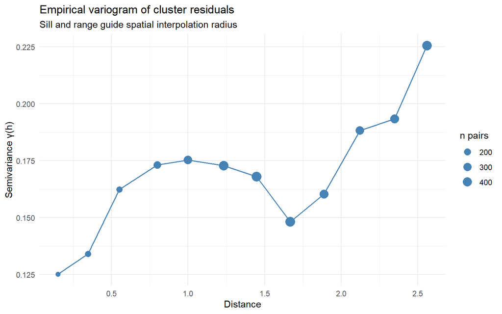

```r
# Illustrate the geostatistical approach conceptually using cluster residuals
vario <- empirical_variogram(cl_resid, n_bins = 12)
plot_variogram(vario) +
  labs(subtitle = "Sill and range guide spatial interpolation radius")
```

**Comparison summary:**

| Method | Strengths | Weaknesses |
| --- | --- | --- |
| Super Learner | Flexible, non-parametric, high predictive accuracy | Black-box, slow bootstrap, needs large $n$ |
| Spatial GAM | Interpretable, posterior uncertainty, spatial smoothing | Assumes additive structure, limited interaction |
| Fay-Herriot | Design-based, shrinks unstable direct estimates | Area-level only, linear linking model |
| Geostatistical | Principled spatial interpolation, kriging SE | Requires stationarity, variogram model choice |

# 12 L. Practical Checklist and Common Failure Modes

## 12.1 The essential checklist

Pre-publication model checklist

| Item | Status |
| --- | --- |
| Cluster-blocked CV (not individual-level randomisation) | ☐ |
| Imputation fitted on training data only | ☐ |
| Standardisation fitted on training data only | ☐ |
| Outcome leakage check (no derived biomarker columns as predictors) | ☐ |
| Calibration assessed (slope ≈ 1, intercept ≈ 0) | ☐ |
| PR-AUC and Brier score reported alongside ROC-AUC | ☐ |
| Bootstrap resamples clusters (not individuals) | ☐ |
| Survey weights applied in prevalence aggregation | ☐ |
| Residual spatial autocorrelation tested (Moran’s I) | ☐ |
| Threshold T tuned on separate data (nested CV if tuning needed) | ☐ |

## 12.2 Common failure modes

**1. Outcome leakage in predictors.** Including derived variables (e.g., haemoglobin from the same survey as ferritin) as covariates will artificially inflate CV performance. Always audit domain prefixes and exclude any variable measured at the same visit as the outcome.

**2. Individual-level CV with cluster data.** With 15 individuals per cluster, a randomly assigned fold will typically contain 14 cluster-mates of each validation individual in the training set, leaking the cluster random effect and over-estimating generalisability.

**3. Geographic identifier inconsistencies.** Merging cluster GPS to Admin2 boundaries may misclassify border clusters. Always visualise the spatial join and inspect mismatches before aggregating.

**4. Temporal misalignment of covariates and biomarkers.** A satellite-derived NDVI raster from a different season than the survey will attenuate or reverse the expected association. Match covariate extraction windows to survey fieldwork dates.

**5. Survey displacement.** DHS GPS clusters are randomly displaced up to 2 km (urban) or 5 km (rural). This attenuates spatially-varying covariate associations. Account for it by using covariates averaged over a buffer radius, not exact-location extracts.

**6. Model transferability assumptions.** A model trained in one country is transferable to another only if: (a) covariate distributions overlap (common support), (b) covariate–biomarker associations are stable across contexts, and (c) measurement protocols for both predictors and outcomes are comparable. Validate explicitly with held-out geographic areas if possible.

## 12.3 Residual analysis

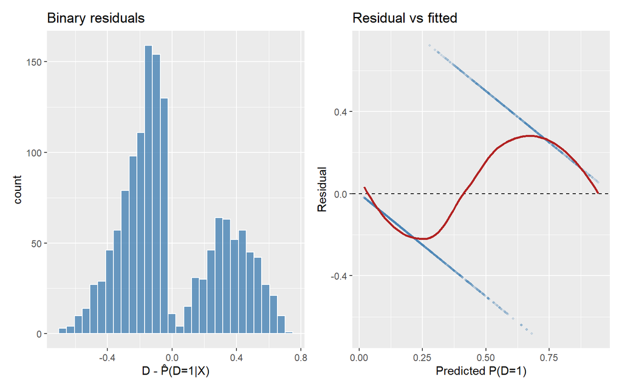

```r
# Final residual check on binary model
df_proc$resid_bin <- df_proc$D - df_proc$pred_bin

p_resid_hist <- ggplot(df_proc, aes(x = resid_bin)) +
  geom_histogram(bins = 30, fill = "steelblue", colour = "white", alpha = 0.8) +
  labs(x = "D - P̂(D=1|X)", title = "Binary residuals")

p_resid_pred <- ggplot(df_proc, aes(x = pred_bin, y = resid_bin)) +
  geom_point(alpha = 0.2, size = 0.8, colour = "steelblue") +
  geom_hline(yintercept = 0, linetype = "dashed") +
  geom_smooth(method = "loess", colour = "firebrick", se = FALSE) +
  labs(x = "Predicted P(D=1)", y = "Residual",
       title = "Residual vs fitted")

p_resid_hist + p_resid_pred
```

## 12.4 Session information

```
#> R version: R version 4.4.2 (2024-10-31 ucrt)
```

```
#> Key packages:
```

```
#>   SuperLearner       2.0.29
#>   glmnet             4.1.8
#>   ranger             0.17.0
#>   mgcv               1.9.1
#>   sf                 1.0.19
#>   spdep              1.3.10
#>   pROC               1.18.5
#>   PRROC              1.3.1
```